# Identifying over-represented GO terms

In this notebook we will identify the over-represented GO terms in the proteins previously identified as changing RNA binding. The steps in this analysis are:

1. Model the relationship between differential RNA binding and an expected bias factor
2. Identify all the over-represented GO terms
3. Filter by FDR and degree of over-representation
4. Plot
5. Compare GO terms over-represented when using `limma` or `lm`

```r
library(tidyverse)
library(goseq)
library(Hmisc)
library(limma)
library(biobroom)

# set up standardised plotting scheme
theme_set(theme_bw(base_size = 20) +
            theme(panel.grid.major=element_blank(),
                  panel.grid.minor=element_blank(),
                  aspect.ratio=1))

cbPalette <- c("#E69F00", "#56B4E9", "#009E73", "#F0E442", "#0072B2", "#D55E00", "#CC79A7", "#999999")
```

We need to source some functions which are stored in a script called “GO.R”.

```r
source("./GO.R")
```

Below, we load the result for differential RNA binding testing from the previous notebooks

```r
limma_rna_binding_fit <- readRDS("../results/limma_rna_binding_fit.rds")

compare_methods <- readRDS("../results/compare_methods_rna_binding_results.rds")
```

In our case, we have reason to suspect that proteins with higher intensity will be more likely to be identified as having significantly altered RNA binding since the variance will be smaller so we will have more power to detect differences.

The first step is to make a probability weight function (PWF) linking the bias factor with the probabilty of significant difference using the `nullp` function.

For this, we need a boolean to indicate which proteins we identify as having a significant change and a vector of the same length which details our bias factor.

The `limma` output contains a “AveExpr” value for each protein which represents the mean intensity. This is precisely the bias factor we are after so we can use this directly.

```r
bias <- compare_methods$AveExpr
print(length(bias))
```

```
[1] 1916
```

```r
limma_rna_binding_fit_treat <- treat(limma_rna_binding_fit, lfc=log2(1.4))

limma_rna_binding_changes <- topTreat(limma_rna_binding_fit_treat, coef = "conditionG1:typeOOPS", n = Inf,
                                      p.value=0.01, adjust.method="BH", confint=0.95)

limma_rna_binding_changes <- limma_rna_binding_changes[limma_rna_binding_changes$logFC>log2(1.5),]

limma_sig_bool <- compare_methods$Row.names %in% rownames(limma_rna_binding_changes)
names(limma_sig_bool) <- compare_methods$Row.names
print(table(limma_sig_bool))
```

```
limma_sig_bool
FALSE  TRUE
 1806   110
```

```r
lm_sig_bool <- (compare_methods$lm_BH < 0.01 & compare_methods$logFC>log2(1.4))
names(lm_sig_bool) <- compare_methods$Row.names
print(table(lm_sig_bool))
```

```
lm_sig_bool
FALSE  TRUE
 1597   319
```

By default, the function expects a genome name and it will go and fetch the bias data. However, we can also just provide this data ourselves. Below, we obtain the PWF and `goseq` outputs plots to show how closely these fit the observed relationship.

```
initial point very close to some inequality constraints
```

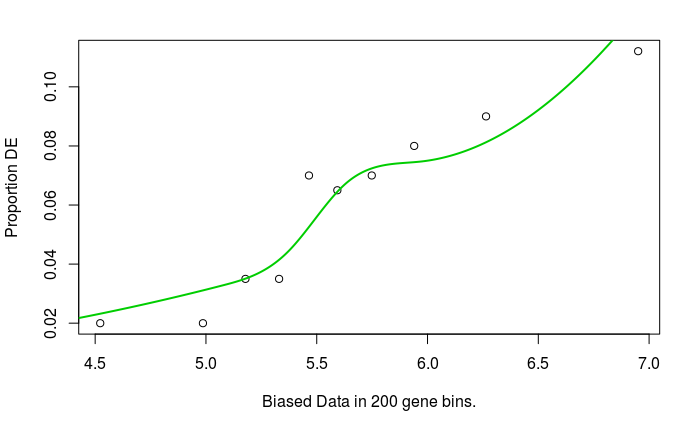

```r
limma_pwf <- nullp(limma_sig_bool, bias.data=bias, plot.fit=TRUE)
```

```
initial point very close to some inequality constraints
```

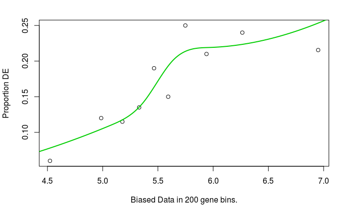

```r
lm_pwf <- nullp(lm_sig_bool, bias.data=bias, plot.fit=TRUE)
```

Now, we need those GO terms from the previous notebook

```r
sapiens.go.full <- readRDS("../results/h_sapiens_go_full.rds")
head(sapiens.go.full)
```

|  | UNIPROTKB | GO.ID | TERM | ONTOLOGY |
| --- | --- | --- | --- | --- |
| 1 | P09874 | GO:0000002 | mitochondrial genome maintenance | BP |
| 2 | Q9UJZ1 | GO:0000002 | mitochondrial genome maintenance | BP |
| 3 | Q9Y243 | GO:0000002 | mitochondrial genome maintenance | BP |
| 4 | Q02078 | GO:0000002 | mitochondrial genome maintenance | BP |
| 5 | Q9BUK6 | GO:0000002 | mitochondrial genome maintenance | BP |
| 6 | Q96RR1 | GO:0000002 | mitochondrial genome maintenance | BP |

And we’re ready to run `goseq`. By default, `goseq` expects a `genome` and will obtain the GO terms automatically. However, if we provide our own to the `gene2cat` argument, it will use this instead. This also means we could use `goseq` to interrogate over-represented KEGG terms, interpro domains, etc by simply providing them at this point.

[output not shown]

We need to adjust the p-values to account for multiple testing. Again, we’ll use the Benjamini-Hochberg method.

```r
limma_over_rep_go$BH <- p.adjust(limma_over_rep_go$over_represented_pvalue, method="BH")
lm_over_rep_go$BH <- p.adjust(lm_over_rep_go$over_represented_pvalue, method="BH")
```

We can filter the output to only include the GO terms which are over-represented at 1% FDR (there are 112 for `limma`)

```r
sig_terms <- limma_over_rep_go %>% filter(BH<0.01)
print(dim(sig_terms))
```

```
[1] 112   8
```

```r
print(head(sig_terms))
```

|  | category | over_represented_pvalue | under_represented_pvalue | numDEInCat | numInCat | term | ontology | BH |
| --- | --- | --- | --- | --- | --- | --- | --- | --- |
| 1 | GO:0044281 | 4.028782e-24 | 1 | 63 | 310 | small molecule metabolic process | BP | 4.769272e-20 |
| 2 | GO:0055114 | 1.958873e-19 | 1 | 32 | 83 | oxidation-reduction process | BP | 1.159457e-15 |
| 3 | GO:0044429 | 3.100699e-19 | 1 | 41 | 159 | mitochondrial part | CC | 1.223536e-15 |
| 4 | GO:0019752 | 4.011556e-18 | 1 | 46 | 203 | carboxylic acid metabolic process | BP | 1.170206e-14 |
| 5 | GO:0043436 | 4.942581e-18 | 1 | 46 | 204 | oxoacid metabolic process | BP | 1.170206e-14 |
| 6 | GO:0006082 | 6.292715e-18 | 1 | 46 | 205 | organic acid metabolic process | BP | 1.241553e-14 |

The function below estimates the effect size, taking into account the bias (using the PWF)

```r
# ------------------------------------------------------------------------------------------------------------
# Function  : 'addAdjustedOverRep' A crude function to add an adjusted estimate of the over-representation of a term
# Input
#           : obj = A data frame with the results from goseq. As generated by GetEnrichedGO
#           : pwf = a PWF from goseq
#           : gene2cat = A dataframe mapping features to categories
# Output  : The input obj + a column with estimated adjusted over-representation for each term ($adj_over_rep)
# ------------------------------------------------------------------------------------------------------------------------

addAdjustedOverRep <- function(obj, pwf, gene2cat){
  len_fore <- sum(pwf$DEgenes)
  len_back <- length(pwf$DEgenes)

  obj$adj_over_rep <- apply(obj[,c("numDEInCat", "numInCat", "category")], MARGIN=1, function(x){
    term_features <- gene2cat[gene2cat[["GO.ID"]]==x[["category"]], "UNIPROTKB"]
    term_weight <- mean(pwf[rownames(pwf) %in% term_features, "pwf"])
    non_term_weight <- mean(pwf[!rownames(pwf) %in% term_features, "pwf"])
    as.numeric(x[['numDEInCat']])/as.numeric(x[['numInCat']]) / (term_weight/non_term_weight) / (len_fore/len_back)})

  return(obj)
}
```

Now we can filter by the estimated over-representation too.

```r
limma_over_rep_go %>% filter(BH<0.01)  %>%
  addAdjustedOverRep(lm_pwf, sapiens.go.full) %>%
  filter(adj_over_rep>2) %>%
  head()
```

|  | category | over_represented_pvalue | under_represented_pvalue | numDEInCat | numInCat | term | ontology | BH | adj_over_rep |
| --- | --- | --- | --- | --- | --- | --- | --- | --- | --- |
| 1 | GO:0055114 | 1.958873e-19 | 1 | 32 | 83 | oxidation-reduction process | BP | 1.159457e-15 | 2.195040 |
| 2 | GO:0045333 | 4.456564e-11 | 1 | 15 | 34 | cellular respiration | BP | 4.058216e-08 | 2.608945 |
| 3 | GO:0015980 | 5.051024e-10 | 1 | 16 | 46 | energy derivation by oxidation of organic compounds | BP | 3.737126e-07 | 2.102115 |
| 4 | GO:0009060 | 7.197845e-09 | 1 | 11 | 22 | aerobic respiration | BP | 3.873095e-06 | 2.831174 |
| 5 | GO:0004812 | 5.568684e-08 | 1 | 11 | 24 | aminoacyl-tRNA ligase activity | MF | 2.354360e-05 | 2.400932 |
| 6 | GO:0016875 | 5.568684e-08 | 1 | 11 | 24 | ligase activity, forming carbon-oxygen bonds | MF | 2.354360e-05 | 2.400932 |

```r
lm_over_rep_go %>% filter(BH<0.01)  %>%
  addAdjustedOverRep(lm_pwf, sapiens.go.full) %>%
  filter(adj_over_rep>2) %>%
  head()
```

|  | category | over_represented_pvalue | under_represented_pvalue | numDEInCat | numInCat | term | ontology | BH | adj_over_rep |
| --- | --- | --- | --- | --- | --- | --- | --- | --- | --- |
| 1 | GO:0044281 | 4.514926e-33 | 1 | 133 | 310 | small molecule metabolic process | BP | 5.344769e-29 | 2.493771 |
| 2 | GO:0043436 | 9.437890e-27 | 1 | 97 | 204 | oxoacid metabolic process | BP | 5.586287e-23 | 2.715729 |
| 3 | GO:0006082 | 1.644155e-26 | 1 | 97 | 205 | organic acid metabolic process | BP | 6.487837e-23 | 2.699929 |
| 4 | GO:0019752 | 3.248454e-26 | 1 | 96 | 203 | carboxylic acid metabolic process | BP | 9.613801e-23 | 2.701236 |
| 5 | GO:0055114 | 4.699760e-21 | 1 | 52 | 83 | oxidation-reduction process | BP | 9.272627e-18 | 3.566940 |
| 6 | GO:0044429 | 2.148131e-19 | 1 | 73 | 159 | mitochondrial part | CC | 3.632796e-16 | 2.715217 |

```r
NA
```

Note that many of the above GO terms are essentially redundant and are simply the same set of proteins with each of the GO terms up the heirachy being over-represented. We can perform a simplification by taking each over-represented GO term, identifying all its offspring and ancesters and removing it if any of the terms above or below are more significantly over-represented.

Below, I’ve wrapped this all up into a function so that we can pass a data.frame of significantly over-represented GO terms and it will remove the redundant terms.

```r
remove_redundant_GO_terms <- function(go_df){

  all_observed_go <- unique(go_df$category) # identify all the GO terms
  all_observed_go <- all_observed_go[!is.na(all_observed_go)] # Remove any NAs

  # Get the ontologies for the GO terms
  ontologies <- AnnotationDbi::select(GO.db, all_observed_go, columns = c('ONTOLOGY'), keytype='GOID')
  ontologies <- setNames(ontologies$ONTOLOGY, ontologies$GOID)

  # Get the mappings from GO term to parent GO terms using functions in GO.R
  go2Offspring <- getAllMappings(all_observed_go, ontologies, verbose=FALSE, direction="offspring")
  go2Ancesters <- getAllMappings(all_observed_go, ontologies, verbose=FALSE, direction="ancester")

  # start with all observed GO terms being retained
  retained <- all_observed_go

  # We want to keep track of the GO IDs we have processed
  processed <- NULL

  # If any GO term has no detected offspring or ancesters, mark them as already processed
  # This will also mean they are always retained
  no_anc_off <- setdiff(all_observed_go, union(names(go2Ancesters), names(go2Offspring)))
  if(length(no_anc_off)>0){
    cat(sprintf("No offspring or ancesters could be found for these terms: %s", no_anc_off))
    processed <- no_anc_off
  }

  # When all observed go terms are in processed, stop while loop
  while(length(setdiff(all_observed_go, processed))!=0){

    # take one of the GO terms
    go_id <- setdiff(all_observed_go, processed)[1]

    # Find all the ancesters and offspring = go_tree
    # (Only include those also observed as over-rep GO)
    go_tree <- union(go2Ancesters[[go_id]], go2Offspring[[go_id]]) %>%
      intersect(all_observed_go) %>% c(go_id)

    top_go <- go_df %>%
      filter(category %in% go_tree) %>% # subset to the terms in go_tree
      arrange(over_represented_pvalue) %>% # order by p-value (ascending by default)
      pull(category) %>%# pull out the category
      head(1) # keep the top GO term

    # We want to remove all ancester and offspring terms within the go_tree for the top GO term
    terms_to_remove <- union(go2Ancesters[[top_go]], go2Offspring[[top_go]]) %>%
      intersect(go_tree)

    processed <- union(processed, go_tree) # all terms in the tree are now considered "processed"

    retained <- setdiff(retained, terms_to_remove) # remove the unwanted terms from retained
  }

  go_df <- go_df %>% filter(category %in% retained) # subset to the retained terms

  return(go_df)
}
```

```r
limma_over_rep_go %>% filter(BH<0.01)  %>%
  addAdjustedOverRep(limma_pwf, sapiens.go.full) %>%
  filter(adj_over_rep>3) %>%
  remove_redundant_GO_terms() %>%
  head()
```

|  | category | over_represented_pvalue | under_represented_pvalue | numDEInCat | numInCat | term | ontology | BH | adj_over_rep |
| --- | --- | --- | --- | --- | --- | --- | --- | --- | --- |
| 1 | GO:0044281 | 4.028782e-24 | 1 | 63 | 310 | small molecule metabolic process | BP | 4.769272e-20 | 3.494409 |
| 2 | GO:0055114 | 1.958873e-19 | 1 | 32 | 83 | oxidation-reduction process | BP | 1.159457e-15 | 6.204881 |
| 3 | GO:0044429 | 3.100699e-19 | 1 | 41 | 159 | mitochondrial part | CC | 1.223536e-15 | 4.640499 |
| 4 | GO:0006091 | 1.414456e-13 | 1 | 27 | 92 | generation of precursor metabolites and energy | BP | 1.860482e-10 | 5.018165 |
| 5 | GO:0017144 | 5.526715e-12 | 1 | 30 | 128 | drug metabolic process | BP | 5.947750e-09 | 3.918863 |
| 6 | GO:0016491 | 6.280439e-11 | 1 | 25 | 95 | oxidoreductase activity | MF | 5.310560e-08 | 4.245300 |

```r
lm_over_rep_go %>% filter(BH<0.01)  %>%
  addAdjustedOverRep(lm_pwf, sapiens.go.full) %>%
  filter(adj_over_rep>3) %>%
  remove_redundant_GO_terms() %>%
  head()
```

|  | category | over_represented_pvalue | under_represented_pvalue | numDEInCat | numInCat | term | ontology | BH | adj_over_rep |
| --- | --- | --- | --- | --- | --- | --- | --- | --- | --- |
| 1 | GO:0055114 | 4.699760e-21 | 1 | 52 | 83 | oxidation-reduction process | BP | 9.272627e-18 | 3.566940 |
| 2 | GO:0044282 | 2.495342e-14 | 1 | 37 | 62 | small molecule catabolic process | BP | 1.969324e-11 | 3.440306 |
| 3 | GO:0004812 | 1.039095e-11 | 1 | 20 | 24 | aminoacyl-tRNA ligase activity | MF | 6.150401e-09 | 4.365332 |
| 4 | GO:0006418 | 2.455402e-10 | 1 | 20 | 26 | tRNA aminoacylation for protein translation | BP | 7.855960e-08 | 3.928257 |
| 5 | GO:0005743 | 2.561231e-09 | 1 | 26 | 48 | mitochondrial inner membrane | CC | 6.890877e-07 | 3.221653 |
| 6 | GO:0006734 | 6.737147e-08 | 1 | 12 | 13 | NADH metabolic process | BP | 1.035771e-05 | 4.298834 |

OK so now we’re getting a more useful set of terms. The next thing we might want to do is some basic plot to show the result. Again, I’ve wrapped this up into a a function below so we can pass the GO dataframe straight through the above pipe to filter the results and then plot the filtered results.

```r
plotTerms <- function(go_df,
                      horizontal=FALSE, # make plot hoizontal
                      plot_top=10,# plot the top n most significant GO terms
                      shorten_term=FALSE){ # shorten the term to max 30 char

  # re-order data frame by p-value
  if(horizontal){
    go_df <- go_df %>% arrange(ontology, over_represented_pvalue)
    go_df <- go_df %>% head(plot_top) # subset to top n most significant terms
  }
  else{
    go_df <- go_df %>% arrange(desc(ontology), desc(over_represented_pvalue))
    go_df <- go_df %>% tail(plot_top) # subset to top n most significant terms
  }

  if(shorten_term){
    go_df$term_for_plot <- substr(go_df$term, 1, 40) # cut at character 40
  }
  else{
    go_df$term_for_plot <- go_df$term
  }

  # add the ontology (BP, MF, CC) to the end of the term
  go_df$term_for_plot <- paste0(go_df$term_for_plot, " (", go_df$ontology, ")")

  # re-level factor make keep plotting order in order of dataframe (ontology, p-value)
  go_df$term_for_plot <- factor(go_df$term_for_plot, levels=rev(go_df$term_for_plot))

  p <- go_df %>%
    ggplot(aes(x=term_for_plot, y=log(adj_over_rep,2), fill=log(BH,10))) +
    geom_bar(stat="identity") + # When geom_bar is plotting a single data point, need to set stat="identity"
    xlab("") +
    ylab("Adjusted\nOver-representation\n(Log2)") +
    scale_fill_continuous(name="BH adj. p-value\n(Log 10)\n", low=cbPalette[5], high="grey30", limits=c(NA, -2)) +
    theme(text=element_text(size=15),
          plot.title=element_text(hjust=0.5))

  if(horizontal){
    p <- p + coord_flip() # Flip the coordinates
  }
  else{
    # If vertical bards, set the x-axis text at an angle so it fits better
    p <- p + theme(axis.text.x=element_text(size=12, angle=30, vjust=1, hjust=1))
  }

  return(list("p"=p, "data"=go_df))
}
```

|  | category | over_represented_pvalue | under_represented_pvalue | numDEInCat | numInCat | term | ontology | BH | adj_over_rep | term_for_plot |
| --- | --- | --- | --- | --- | --- | --- | --- | --- | --- | --- |
| 1 | GO:0044281 | 4.028782e-24 | 1.0000000 | 63 | 310 | small molecule metabolic process | BP | 4.769272e-20 | 3.494409 | small molecule metabolic process (BP) |
| 2 | GO:0055114 | 1.958873e-19 | 1.0000000 | 32 | 83 | oxidation-reduction process | BP | 1.159457e-15 | 6.204881 | oxidation-reduction process (BP) |
| 3 | GO:0006091 | 1.414456e-13 | 1.0000000 | 27 | 92 | generation of precursor metabolites and energy | BP | 1.860482e-10 | 5.018165 | generation of precursor metabolites and (BP) |
| 4 | GO:0017144 | 5.526715e-12 | 1.0000000 | 30 | 128 | drug metabolic process | BP | 5.947750e-09 | 3.918863 | drug metabolic process (BP) |
| 5 | GO:0051186 | 1.245389e-06 | 0.9999997 | 21 | 115 | cofactor metabolic process | BP | 2.541882e-04 | 3.113399 | cofactor metabolic process (BP) |
| 6 | GO:1901137 | 1.910455e-06 | 0.9999996 | 20 | 107 | carbohydrate derivative biosynthetic process | BP | 3.627390e-04 | 3.145541 | carbohydrate derivative biosynthetic pro (BP) |
| 7 | GO:1901998 | 2.425164e-06 | 0.9999999 | 7 | 10 | toxin transport | BP | 4.284939e-04 | 8.233090 | toxin transport (BP) |
| 8 | GO:0030258 | 4.666279e-06 | 0.9999997 | 8 | 21 | lipid modification | BP | 7.672140e-04 | 7.426975 | lipid modification (BP) |
| 9 | GO:0005975 | 1.073440e-05 | 0.9999976 | 17 | 89 | carbohydrate metabolic process | BP | 1.588422e-03 | 3.177366 | carbohydrate metabolic process (BP) |
| 10 | GO:0008202 | 1.109125e-05 | 0.9999987 | 10 | 35 | steroid metabolic process | BP | 1.606653e-03 | 5.153704 | steroid metabolic process (BP) |

[output cut: 7 more lines]

```
NA
```

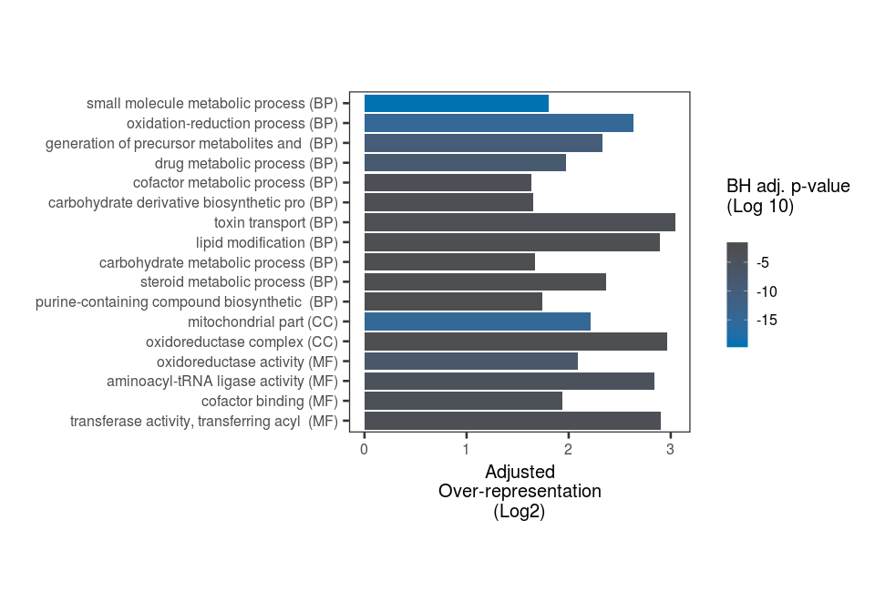

```r
limma_over_rep_go %>% filter(BH<0.01)  %>%
  addAdjustedOverRep(limma_pwf, sapiens.go.full) %>%
  filter(adj_over_rep>3) %>%
  remove_redundant_GO_terms() %>%
  plotTerms(horizontal=TRUE, shorten_term=TRUE, plot_top=20)
```

|  | category | over_represented_pvalue | under_represented_pvalue | numDEInCat | numInCat | term | ontology | BH | adj_over_rep | term_for_plot |
| --- | --- | --- | --- | --- | --- | --- | --- | --- | --- | --- |
| 1 | GO:0055114 | 4.699760e-21 | 1.0000000 | 52 | 83 | oxidation-reduction process | BP | 9.272627e-18 | 3.566940 | oxidation-reduction process (BP) |
| 2 | GO:0044282 | 2.495342e-14 | 1.0000000 | 37 | 62 | small molecule catabolic process | BP | 1.969324e-11 | 3.440306 | small molecule catabolic process (BP) |
| 3 | GO:0006418 | 2.455402e-10 | 1.0000000 | 20 | 26 | tRNA aminoacylation for protein translation | BP | 7.855960e-08 | 3.928257 | tRNA aminoacylation for protein translat (BP) |
| 4 | GO:0006734 | 6.737147e-08 | 1.0000000 | 12 | 13 | NADH metabolic process | BP | 1.035771e-05 | 4.298834 | NADH metabolic process (BP) |
| 5 | GO:0006006 | 1.455207e-07 | 1.0000000 | 21 | 38 | glucose metabolic process | BP | 1.980085e-05 | 3.111141 | glucose metabolic process (BP) |
| 6 | GO:0033209 | 4.392061e-07 | 0.9999999 | 18 | 31 | tumor necrosis factor-mediated signaling pathway | BP | 5.147843e-05 | 3.268283 | tumor necrosis factor-mediated signaling (BP) |
| 7 | GO:0016999 | 5.618775e-07 | 0.9999999 | 18 | 32 | antibiotic metabolic process | BP | 6.521084e-05 | 3.260468 | antibiotic metabolic process (BP) |
| 8 | GO:0046364 | 6.939182e-07 | 0.9999999 | 16 | 25 | monosaccharide biosynthetic process | BP | 7.975343e-05 | 3.377015 | monosaccharide biosynthetic process (BP) |
| 9 | GO:1901998 | 6.388143e-06 | 0.9999998 | 9 | 10 | toxin transport | BP | 5.817141e-04 | 4.160712 | toxin transport (BP) |
| 10 | GO:1904874 | 7.699857e-06 | 0.9999996 | 10 | 12 | positive regulation of telomerase RNA localization to Cajal body | BP | 6.858492e-04 | 3.813483 | positive regulation of telomerase RNA lo (BP) |

[output cut: 10 more lines]

```
NA
```

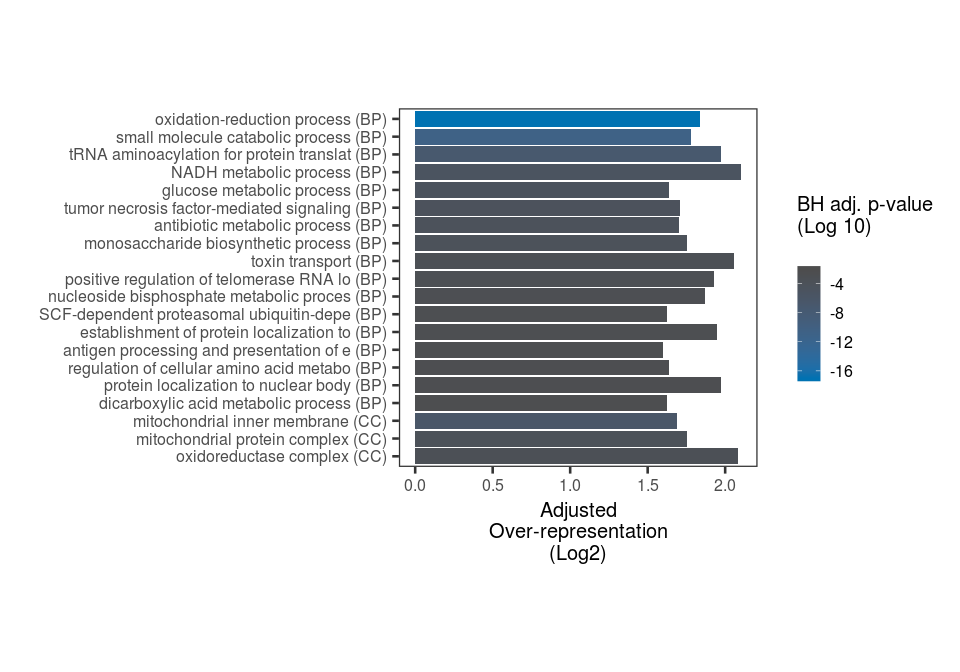

```r
lm_over_rep_go %>% filter(BH<0.01)  %>%
  addAdjustedOverRep(lm_pwf, sapiens.go.full) %>%
  filter(adj_over_rep>3) %>%
  remove_redundant_GO_terms() %>%
  plotTerms(horizontal=TRUE, shorten_term=TRUE, plot_top=20)
```

Ok, so now we have a reasonable list of over-represented GO terms and some pretty plots to show off our results…

```r
lm_over_rep_go %>% filter(term=="tRNA aminoacylation for protein translation") %>%
  addAdjustedOverRep(lm_pwf, sapiens.go.full)  %>%
  head(10)
```

|  | category | over_represented_pvalue | under_represented_pvalue | numDEInCat | numInCat | term | ontology | BH | adj_over_rep |
| --- | --- | --- | --- | --- | --- | --- | --- | --- | --- |
| 1 | GO:0006418 | 2.455402e-10 | 1 | 20 | 26 | tRNA aminoacylation for protein translation | BP | 7.85596e-08 | 3.928257 |

```r
limma_over_rep_go %>% filter(term=="tRNA aminoacylation for protein translation") %>%
  addAdjustedOverRep(lm_pwf, sapiens.go.full)  %>%
  head(10)
```

|  | category | over_represented_pvalue | under_represented_pvalue | numDEInCat | numInCat | term | ontology | BH | adj_over_rep |
| --- | --- | --- | --- | --- | --- | --- | --- | --- | --- |
| 1 | GO:0006418 | 2.046793e-07 | 1 | 11 | 26 | tRNA aminoacylation for protein translation | BP | 6.376299e-05 | 2.160541 |

```r
NA
```

We want to take a look at the intensity values, so let’s make that `plotIntensities()` function again

```r
combined_intensities <- readRDS("../results/combined_intensities.rds")

plotIntensities <- function(obj){

  p <- tidy(obj, addPheno=TRUE) %>%
    ggplot(aes(Condition, value, colour=Type, group=Type)) +
    geom_point() +
    stat_summary(geom="line", fun.y=mean) +
    facet_wrap(~gene, scales='free') +
    ylab("Intensity (log2)")

  invisible(p)
}
```

If we take a look at the intensity values for these 26 proteins annotated with “tRNA aminoacylation for protein translation”, most do seem to have a clear increase in RNA binding. Note that not all of these are cytosolic tRNA ligases. Q5JPH6 + Q5JTZ9 are mitchondrial tRNA ligase. Q15181=Inorganic pyrophosphatase and Q12904 & Q13155 interact with the Aminoacyl tRNA synthase complex.

So, why does `limma` only detect 11/26 of these as increasing RNA binding given the apparent signficiant changes…

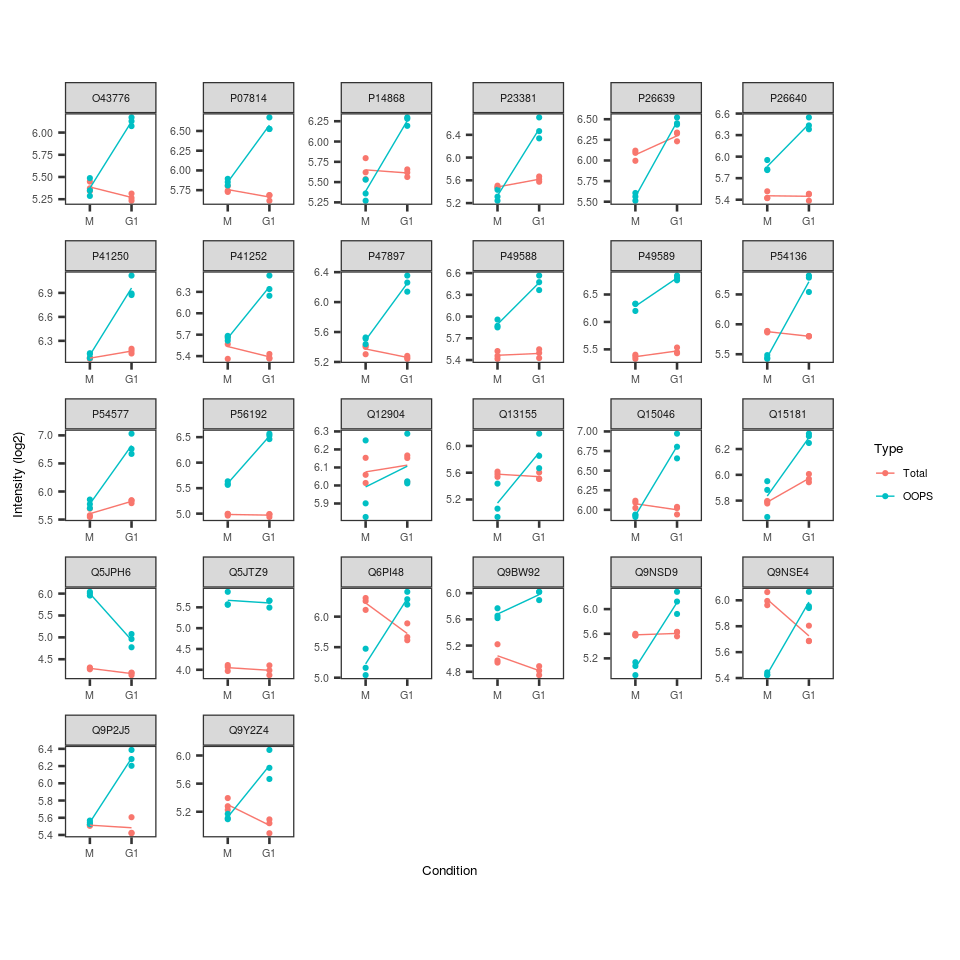

```r
tRNA_aa <- sapiens.go.full %>%
  filter(TERM=="tRNA aminoacylation for protein translation") %>%
  pull(UNIPROTKB)

tRNA_aa_intensities <- combined_intensities[intersect(rownames(combined_intensities), tRNA_aa),] %>%
  plotIntensities()

print(tRNA_aa_intensities + theme(text=element_text(size=10)))
```

Next, we compare the p-values again. Note that the four proteins not in the bottom left quadrant (e.g <1% FDR with both `lm` and `limma`) are the two Mt tRNA-ligases and the two aminoacyl tRNA synthase complex interactors.

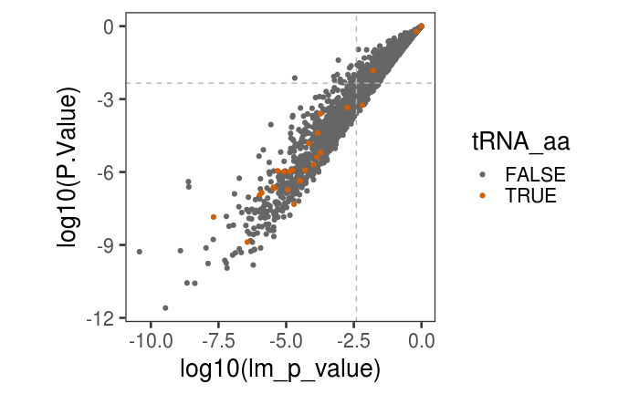

```r
max_p_sig_lm <- compare_methods %>% filter(lm_BH<0.01) %>% pull(lm_p_value) %>% max()
max_p_sig_limma <- compare_methods %>% filter(adj.P.Val<0.01) %>% pull(P.Value) %>% max()

compare_methods %>%
  mutate(tRNA_aa=Row.names %in% tRNA_aa) %>%
  arrange(tRNA_aa) %>%
  ggplot(aes(x=log10(lm_p_value), y=log10(P.Value), colour=tRNA_aa)) +
  geom_point() +
  scale_colour_manual(values=c("grey40", cbPalette[6])) +
  geom_vline(xintercept=log10(max_p_sig_lm), linetype=2, colour="grey70") +
  geom_hline(yintercept=log10(max_p_sig_limma), linetype=2,colour="grey70")
```

Finally, we look at the point estimates for the fold change. The green dashed lines represent our 1.4-fold threshold. The dashed grey-line is the threshold for the BH adjusted p-value being < 0.01.

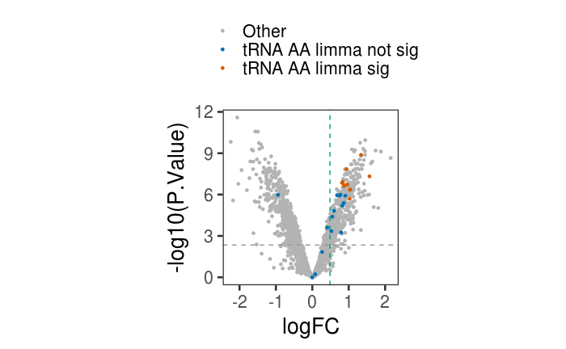

```r
max_p_sig_limma <- compare_methods %>% filter(adj.P.Val<0.01) %>% pull(P.Value) %>% max()

compare_methods %>%
  mutate(tRNA_aa=Row.names %in% tRNA_aa) %>%
  mutate(limma_sig=Row.names %in% rownames(limma_rna_binding_changes)) %>%
  mutate(tRNA_aa_limma=recode(interaction(tRNA_aa, limma_sig),
                              "TRUE.TRUE"="tRNA AA limma sig",
                              "TRUE.FALSE"="tRNA AA limma not sig",
                              "FALSE.TRUE"="Other",
                              "FALSE.FALSE"="Other")) %>%
  arrange(tRNA_aa) %>%
  ggplot(aes(logFC, -log10(P.Value), colour=tRNA_aa_limma)) +
  geom_point(size=1) +
  scale_colour_manual(values=c("grey70", cbPalette[5], cbPalette[6]), name="") +
  geom_vline(xintercept=log2(1.4), linetype=2, colour=cbPalette[3]) +
  geom_hline(yintercept=-log10(max_p_sig_limma), linetype=2, colour="grey60") +
  theme(legend.position="top", legend.direction=2)
```

This demonstrates the downsides of applying a thresholds to the confidence interval for the estimated fold change when we don’t know what fold change is biological relevant. These proteins were subsequently shown to have a consistent (if still slight) change in RNA binding in a Thymidine + Nocadazole experiment suggesting this is probably a real change in RNA binding. So, while a threshold on the log fold change is a very sensible approach, be careful about what threshold you use!

And that’s the end of the workshop!